# Data Analysis 6 by Eric Braun

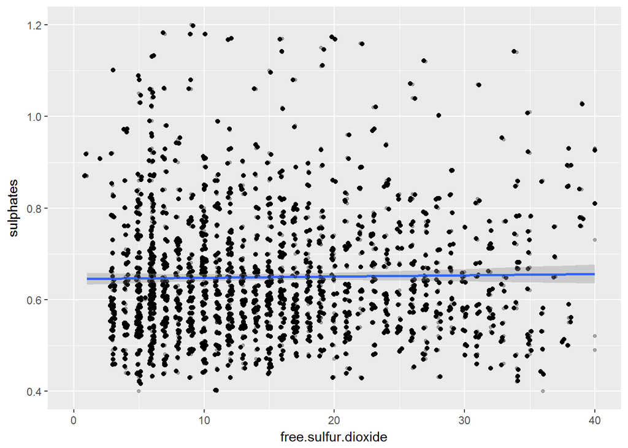

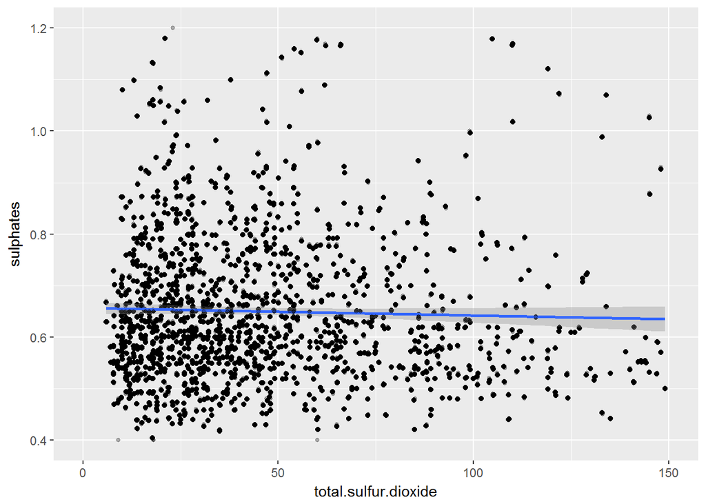

```
## [1] 0.6676665
```

```
## [1] 0.05165757
```

```
## [1] 0.04294684
```

There is a fairly strong relationship of .668 between free and total sulfur dioxides. Oddly there is only relationship of .051 between free sulfur dioxides and sulphates and an even lower correlation of .042 between total sulfur dioxides and sulphates. This is unusual as sulfur dioxide is generally considered a kind of sulphate.

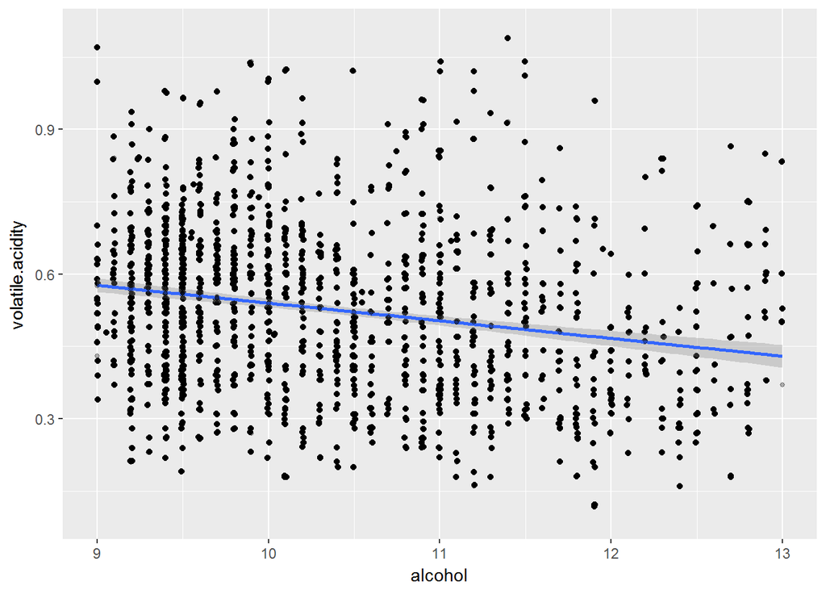

```
## [1] -0.202288
```

There is a medium negative correlation of -.202 between alcohol and volatile acidity.

# Bivariate Analysis

The first question I had involved what variables affected quality in what way. There strongest positive correlations were found in alcohol and sulphate content. It is worth noting that there are many who would rather not drink wine with added sulphates. But based on the data they seem to be doing their job of stabilizing the wine and improving its quality.

The strongest negative factor in the wines is volatile acidity. This makes sense after all volatile acidity is associated with vinegar and other unwanted acids.I will return to volatile acids later in this analysis.

Citric and fixed acids both seem to have some positive correlation with quality with citric acid having a stronger relationship.

pH, free sulfur dioxide and residual sugar both seem to have a mostly neutral relationship with quality. pH and free sulfur dioxide is slightly negative and residual sugar is slightly positive but none seem as important as other factors. Interestingly, residual sugar showsa large amount of clumping on the left side of the graph.This would suggest that wines with less sugar are judged on other factors while wines with more sugar begin to benefit, again ever so slightly, from being a little sweeter.

Density seems to have a low negative relationship with quality. This could suggest that less desirable chemicals may be slightly more dense or that more desirable chemicals may be less dense. Either way, this is a secondary consideration.

Fianlly, chlorides and total sulfur dioxide have a moderate negative correlation with quality. Chlorides are associated with bitter, salty andf soapy flavors, which are hardly popular in wine. Total sulfur dioxide is an interesting case. Total sulfur dioxide is the sum of both free and chemically bound sulfur dioxide compounds. We have data on free sulfur dioxide and can infer something about bound sulfur dioxide from the graphs. Since total sulfur dioxide has a stronger negative correlation than free sulfur dioxide, this would suggest that bound sulfur compounds are more detrimental to the overall quality than free sulfur compounds.

Putting this all together, the best red wines have more alcohol and use sulphates, but not sulfur dioxide, to stabilize the wine. There are more fixed and citric acid, but less volatile acids. Density and pH may vary and there is a slight chance it is a little sweet.

But that is not the end of the analysis. I was also curious at how some of the other features related to each other. I began by exploring the various kinds of acids. Citric acid is often considered a kind of fixed acid, so I was curious how those variables would compare in the dataset. Interestingly there are three strong correlations. Citric acid and fixed acid seem to be very strongly positively correlated, while volatile acidity is negatively correlated with the other two kinds of acid.

Another set of variables that were related were the sulfure dioxide variables and the sulphate content. Free sulfur dioxide is a part of total sulfur dioxide and both are considered sulphates. Interestingly, sulphates do not correlate strongly with either free or total sulfur dioxide, although both relationships are positive. Total and fixed sulfur dioxide have a medium positive correlation, which, again, was less than expected.

Finally, I waned to see how volatile acidity and alcohol compared. Volatile acids are often formed when something goes wrong in the fermentation process producing vinegars instead of alcohol. The expected result would be less volatile acidity as alcohol increases. We do see this effect, although it is a medium correlation.

# Multivariate Plots Section

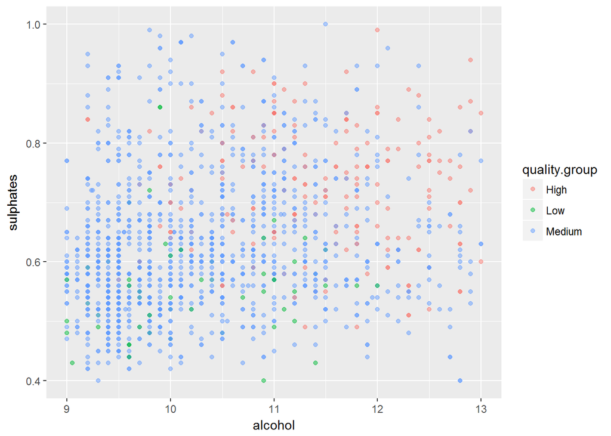

Here we can see the relationship between alcohol and sulppates with a third variable added for quality. I chose these two based on their high correlation with quality. As expected, the more alcohol and sulphates rise together, the better the quality.

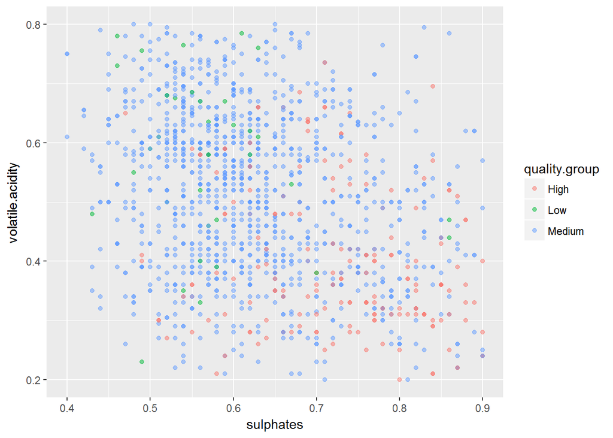

Next I looked at the strongest positive and negative correlations with quality, sulphates and volatile acidity. As expected, the more sulphates with less volatile acids, the better the quality.

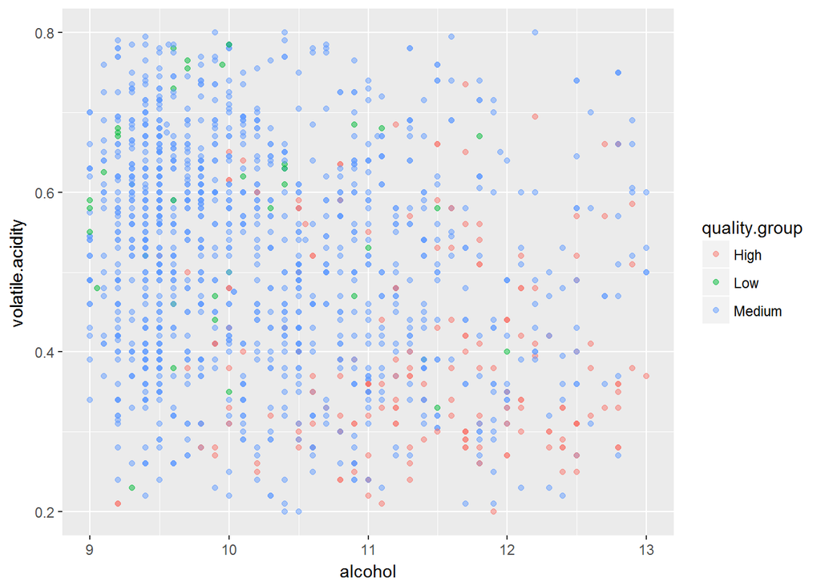

Alcohol and volatile acidity show a similar trend. The more alcohol and less volatile acidity, the better the quality.

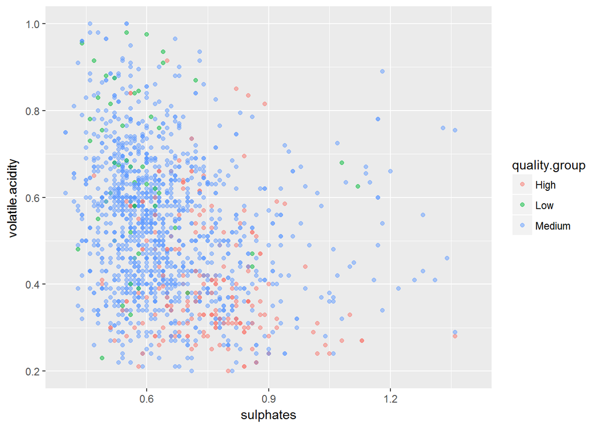

Here we see the relationship between volatile acids and sulphates. More sulphates means better quality, but the relationship seems strongest when volatile acids are low.

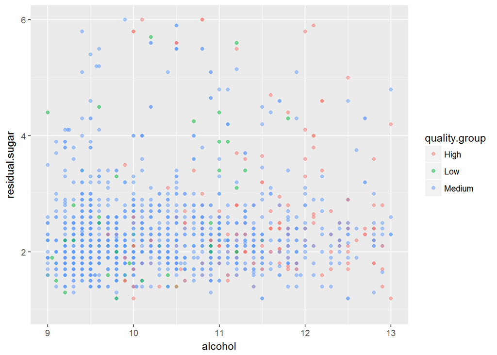

At this point, I checked my intuitions by comparing a variable with high correlation with ine that had very little. As expected residual sugar had little correlation with quality before and we can see the same results here.

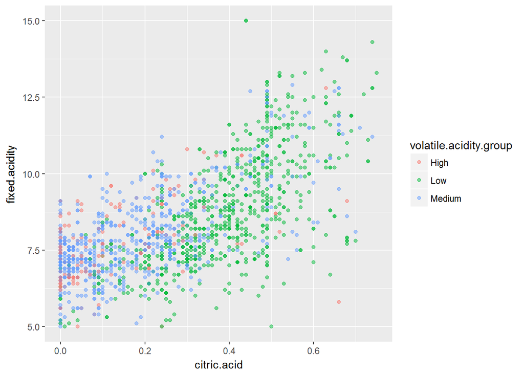

Here I analyzed the relationship between the various kinds of acids. We can see that as fixed and citric acids increase, there is a lower amount of volatile acids.

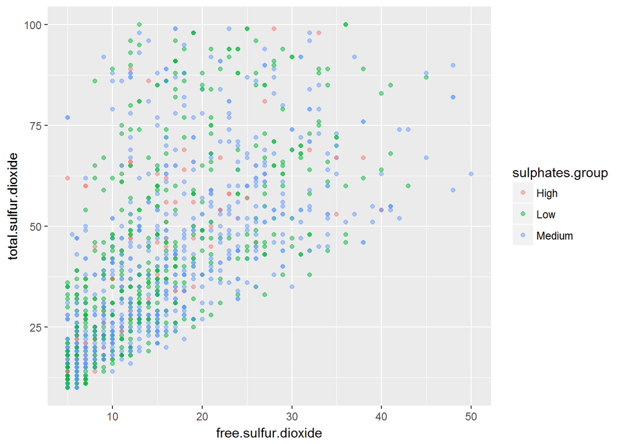

Comparing the various forms of sulfur dioxide to the sulphate groups we can see that as total sulfur dioxide and free sulfur dioxide rise, there is a less consistent pattern, although there is less in the medium and low range.

# Multivariate Analysis

I tested my intuitions from the bivariate plots and found they held up. First, I created three new variables where I divided a previous variable into three boxes- High, Medium and Low. I did this for quality,volatile acidity and sulphates tomake them easier to see on their respective plots.

We can see that as alcohol and sulphates increase, quality also increases, that fixed and citric acidity are negatively correlated with volatile acidity. Volatile acidity and alcohol have the opposite relationsip. We can see that as fixed and citric acids rise together as volatile acids drop.

Once again there is less of a clear cut relationship between sulphates and sulfur dioxide than would be expected given that sulfur dioxide is usually classified as a sulphate.

# Final Plots and Summary

### Plot One

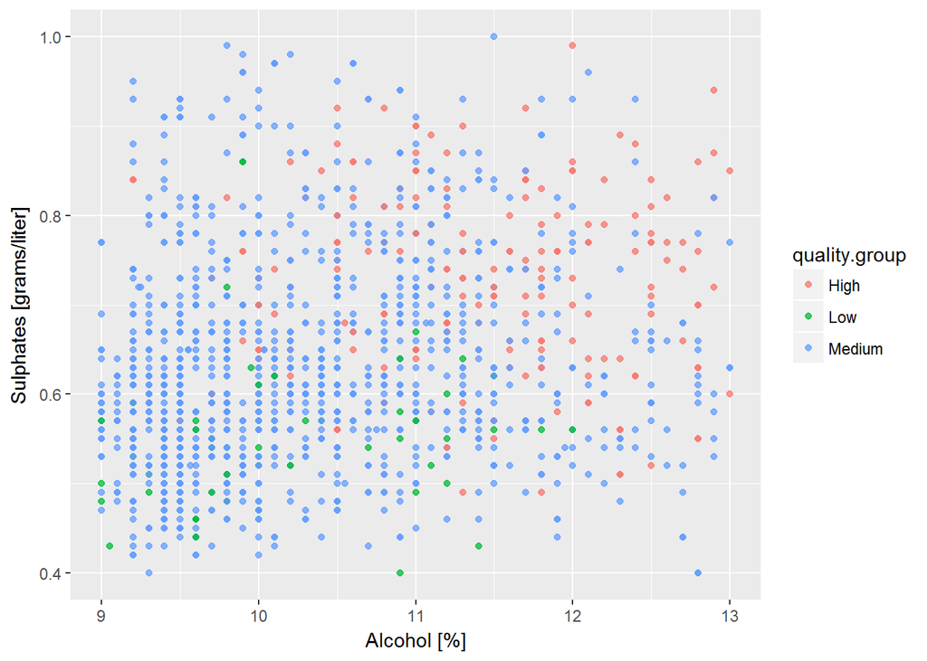

### Description One

This graph shows the relationship between the two variables most strongly tied to an increase in quality. It shows that both alcohol content and sulphates are important for a high quality wine. A closer look also reveals that there are more low quality wine high in alcohol and low in sulphates than low in alcohol and high in sulphates. Given the bad reputation added sulphates has, this shows that it can be the crucial difference in quality.

### Plot Two

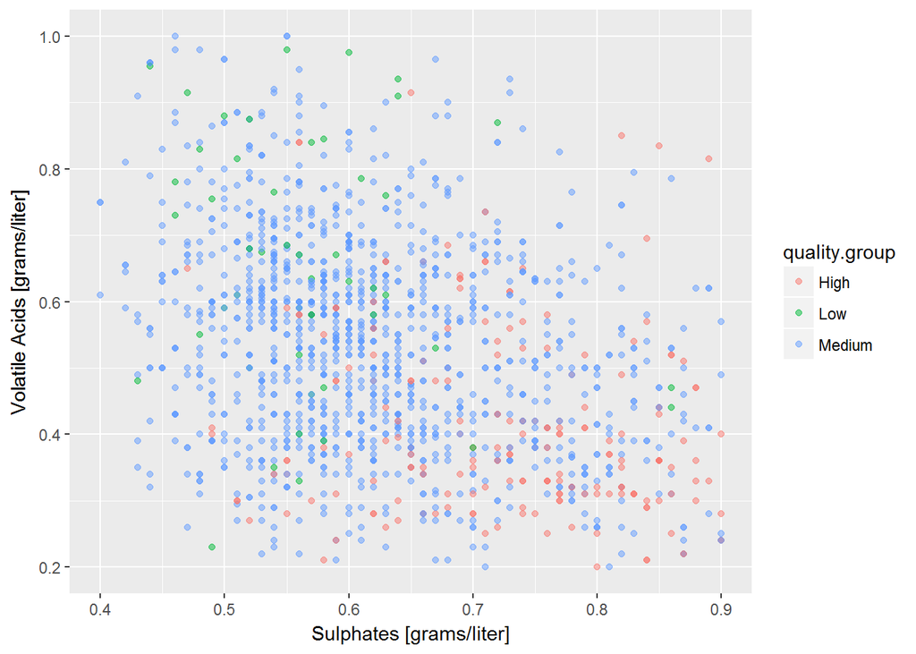

### Description Two

Here we see sulphates again, but this time weighed against the strongest negative predictor for quality. Volatile acids can occur when wine doesn’t properly ferment and sulphates are added to stabilize the wine. We would expect to see the relationship we see above, with more sulphates meaning better wine AND lower levels of volatile acidity.

### Plot Three

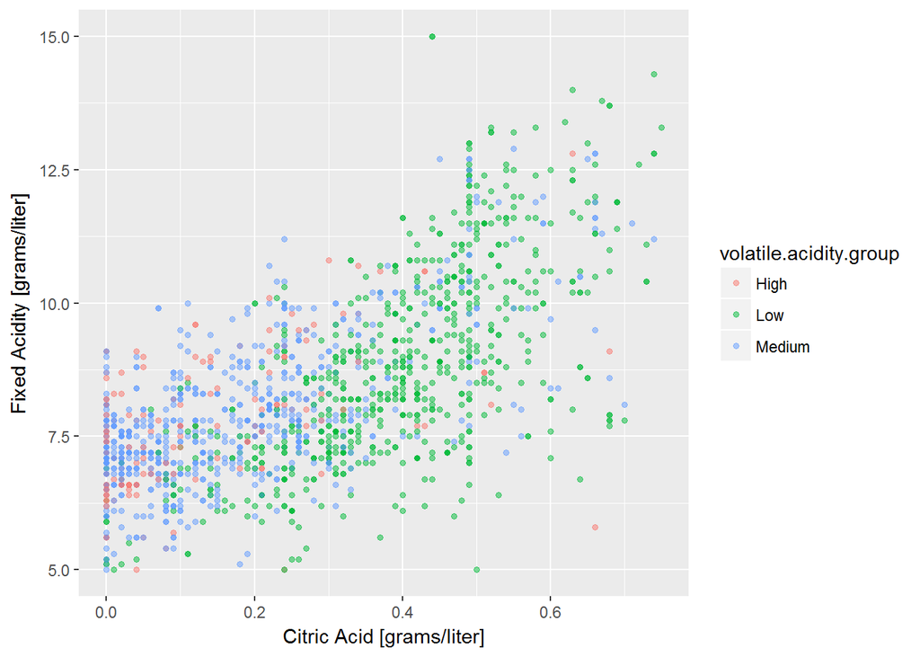

### Description Three

This time I am looking at the relationship between volatile and other kinds of acidity. There is a very strong relationship in this graph, showing that as citric and fixed acidity levels rise, volatile acids drop significantly. ——

# Reflection

There were some interesting patterns to the data. Sulphates and alcohol content corresponded quite closely with quality, which as mentioned above, was a surprise as sulphates are generally seen negatively in the wine world.

Acid levels are also important, with fixed and citric acids being positively correlated with quality, but more weakly and volatile acid negatively correlated but quite strongly. The acids seem to occur in clusters, which would be interesting to explore in a future study.

Similarly, for future analyses it would be interesting to get into the differences between sulfur dioxides and sulphates as they are both sulfur compounds and, while one is closely correlated with quality the other is not and they don’t correlate with each other despite sulfur dioxide being a type of sulphate. Whether this is due to sulfur dioxide and sulphates being seperate from each other or because other sulphates tip the scale in the opposite direction is unclear from this data set.

In a similar vein, citric acid is usually considered to be a kind of fixed acid. This raises some questions about those two acids in the data set. This could also explain the large number of zero values in the citric acid variable. A future study could do more to disambiguate these two.

Chlorides appear to be bad for quality, but not tied to any particular variable. A further exploration of that and density, another variable weakly correlated negatively to quality could be warranted.

It would be interesting to explore the role of chlorides more extensively in a future study.

In my analysis, I found it difficult to visualize some of the trends relating multiple variables. I fixed this problem by clustering the variables into different “buckets” and using those as the color factor on the scatterplot.

As mentioned above, there was some ambiguity about the exact meaning and relationship of the variables. Sulfur dioxide does not seem to be related to sulphates- is this because they are categorized seperately in the data set or because other sulphates make a big difference? Citric acid and fixed acid correlate strongly- is this because citric acid is included as a fixed acid or do those variables co-occur in the data for another reason? Does this relate to the high number of zero values in the citric acid column? For now these questions remain unanswered.

For future study it would be nice to have a larger data set to play with, and perhaps include more variables for analysis, such as price, location of the vineyard, age of the wine etc. There have been interesting studies showing that even experts can rate a cheap wine more highly if it is put in a fancy bottle.

Overall the data suggests that the optimal wine had low volatile acids, low chlorides, higher levels of sulphates and alcohol as well as more citric and fixed acids.